# Pizza Sales - A Case Study

### Preprocessing

Please refer to `./scripts/clean_data.R` for loading, tidying the raw data, and creating some new features. After loading the relevant part of the raw excel file, the following steps were done:

1. Clean variable names
2. Clean `year` and `week` variables
3. Filter data for week 53
4. Create a clean `date` variable from `year` and `week`
5. Combine all calendar variables to a single `holiday` variable
6. Sum all own campaign variables to single `own_campaigns` variable, since they do not overlapo in time
7. Sum all competitor campaign variables to single `competitor_campaigns_sum` variable
8. Average all competitor campaign variables to single `competitor_campaigns_mean` variable
9. Sum all own and competitor campaign variables to single `campaigns_sum` variable
10. Select relevant variables and write data to `./data/processed/data_clean.feather`

```r
source("./scripts/clean_data.R")
```

Load and preview tidy data frame.

```r
data <- feather::read_feather("./data/processed/data_clean.feather") %>%
  mutate(
    year = as.integer(year),
    week = as.integer(week)
  )

head(data) %>% tibble()
```

| year | week | date | pizza | price_offer | holiday | temperature | precipitation | sun | own_campaigns | campaigns_sum | competitor_campaigns_mean | competitor_campaigns_sum | competitor_1 | competitor_2 | competitor_3 | competitor_4 | competitor_5 | competitor_6 | competitor_7 |
| --- | --- | --- | --- | --- | --- | --- | --- | --- | --- | --- | --- | --- | --- | --- | --- | --- | --- | --- | --- |
| 2017 | 1 | 2017-01-02 | 100.0000 | 0.0000000 | 0 | 1.3176236 | 38.378854 | 2.313863 | 0 | 31.4 | 4.485714 | 31.4 | 0 | 0.0 | 0 | 0 | 0 | 31.4 | 0 |
| 2017 | 2 | 2017-01-09 | 221.4754 | 15.2840348 | 0 | 1.0950881 | 47.073025 | 1.563084 | 0 | 22.0 | 3.142857 | 22.0 | 0 | 0.0 | 0 | 0 | 0 | 22.0 | 0 |
| 2017 | 3 | 2017-01-16 | 131.2703 | 2.6571293 | 0 | -0.9988291 | 28.243873 | 3.924862 | 0 | 115.2 | 16.457143 | 115.2 | 0 | 102.9 | 0 | 0 | 0 | 12.3 | 0 |
| 2017 | 4 | 2017-01-23 | 127.8533 | 2.4130594 | 0 | -6.6542909 | 15.761124 | 7.094424 | 0 | 178.4 | 25.485714 | 178.4 | 0 | 159.4 | 0 | 0 | 0 | 19.0 | 0 |
| 2017 | 5 | 2017-01-30 | 146.7554 | 4.3381326 | 0 | 0.2510722 | 28.865521 | 3.882068 | 0 | 17.0 | 2.428571 | 17.0 | 0 | 0.0 | 0 | 0 | 0 | 17.0 | 0 |
| 2017 | 6 | 2017-02-06 | 114.3695 | 0.2032814 | 0 | -8.0983947 | 7.970033 | 11.050375 | 0 | 28.7 | 4.100000 | 28.7 | 0 | 0.0 | 0 | 0 | 0 | 28.7 | 0 |

A first glimpse at the central tendency our variables to get a first idea of our data set.

```r
data %>%
  select(-c(date, holiday, temperature, sun, precipitation, competitor_1:competitor_7)) %>%
  psych::describe(skew = FALSE)
```

|  | vars | n | mean | sd | min | max | range | se |
| --- | --- | --- | --- | --- | --- | --- | --- | --- |
| year | 1 | 260 | 2019.000000 | 1.416941 | 2017.0000000 | 2021.00000 | 4.00000 | 0.08787496 |
| week | 2 | 260 | 26.500000 | 15.037277 | 1.0000000 | 52.00000 | 51.00000 | 0.93257231 |
| pizza | 3 | 260 | 135.741268 | 35.456315 | 66.8740948 | 274.77972 | 207.90563 | 2.19890729 |
| price_offer | 4 | 260 | 3.853701 | 6.116545 | 0.0000000 | 33.99354 | 33.99354 | 0.37933203 |
| own_campaigns | 5 | 260 | 35.976154 | 63.929200 | 0.0000000 | 245.30000 | 245.30000 | 3.96472067 |
| campaigns_sum | 6 | 260 | 238.920006 | 179.636766 | 4.5000000 | 877.10000 | 872.60000 | 11.14059929 |
| competitor_campaigns_mean | 7 | 260 | 28.991979 | 23.559105 | 0.6428571 | 119.27143 | 118.62857 | 1.46107369 |
| competitor_campaigns_sum | 8 | 260 | 202.943852 | 164.913737 | 4.5000000 | 834.90000 | 830.40000 | 10.22751581 |

We can see that we have **data from five years 2017-2021.** Our **own campaigns reach on average more people than our competitors’ campaigns** even though our reach varies way more. However, all competitors combined have of course a way greater reach than our campaigns.

### Task 1: Plot variables

Let’s first have a look at our main **KPI pizza sales** from 2017 through 2021:

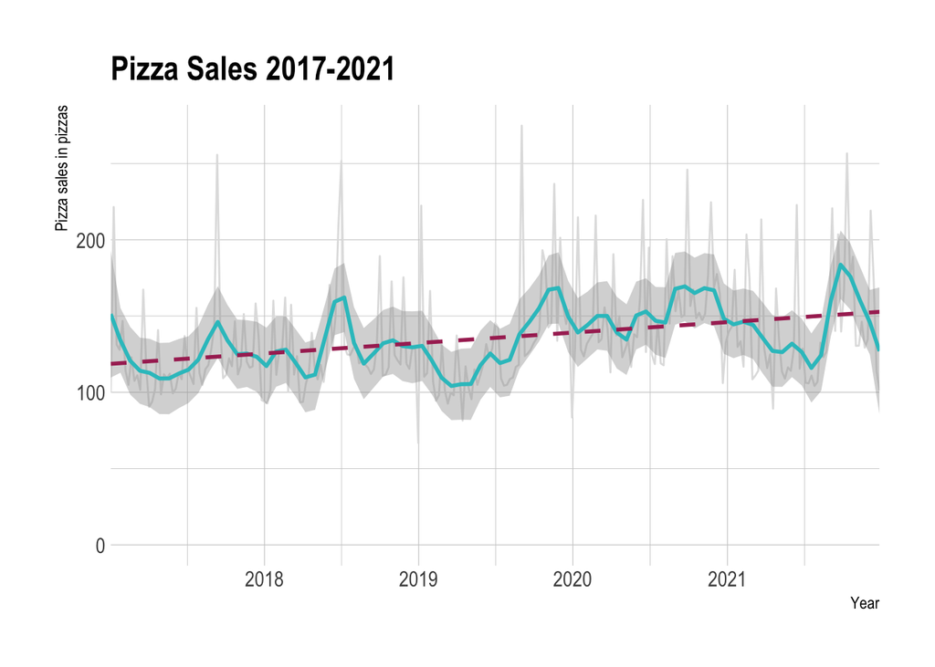

```r
data %>%
  ggplot(aes(x = date, y = pizza)) +
  ## Add pizza sales
  geom_line(aes(x = date, y = pizza),
    color = "#E0E0E0"
  ) +
  ylim(c(0, max(data$pizza))) +
  ## 4-week moving avg
  stat_smooth(
    method = "loess",
    span = 4 / 52,
    color = "#2EC2C7"
  ) +
  ## Add trendline
  geom_smooth(
    method = "lm",
    se = FALSE,
    color = "#A92F62",
    linetype = "dashed"
  ) +
  ## Style
  ggtitle("Pizza Sales 2017-2021") +
  ylab("Pizza sales in pizzas") +
  theme_ipsum(
    plot_title_face = "plain",
    plot_title_size = 14,
    grid = "Y"
  ) +
  scale_x_date(expand = c(0, 0)) +
  xlab("Year") +
  theme_ipsum(grid = TRUE)
```

First, let’s look at the same data aggregated by year.

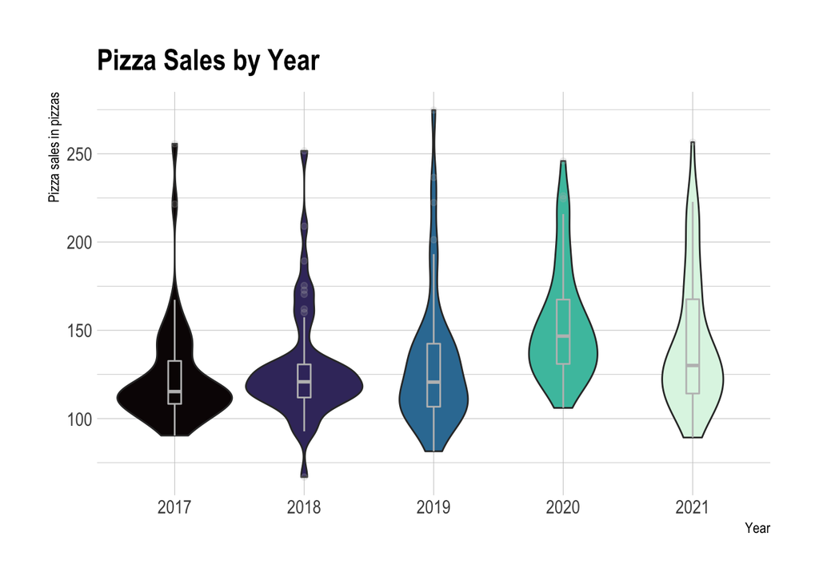

```r
data %>%
  ggplot(aes(x = as.factor(year), y = pizza, fill = as.factor(year))) +
  geom_violin() +
  geom_boxplot(width = 0.1, color = "grey", alpha = 0.2) +
  scale_fill_viridis(discrete = TRUE, option = "G") +
  theme_ipsum() +
  theme(
    legend.position = "none",
  ) +
  ggtitle("Pizza Sales by Year") +
  xlab("Year") +
  ylab("Pizza sales in pizzas")
```

We see that the trend line in the first plot missed that 2021 actually saw a slight decrease in sales, which we can also see in below table that gives us **total sales per year.**

```r
data %>%
  group_by(year) %>%
  summarise(total_pizza = round(sum(pizza), 2)) %>%
  tibble()
```

| year | total_pizza |
| --- | --- |
| 2017 | 6431.56 |
| 2018 | 6673.50 |
| 2019 | 6807.43 |
| 2020 | 7957.85 |
| 2021 | 7422.39 |

Let’s look at the same data but with some other variables that could drive our sales, beginning with **sales offer**, which gives us the deviation from the standard price of our frozen pizza in percent.

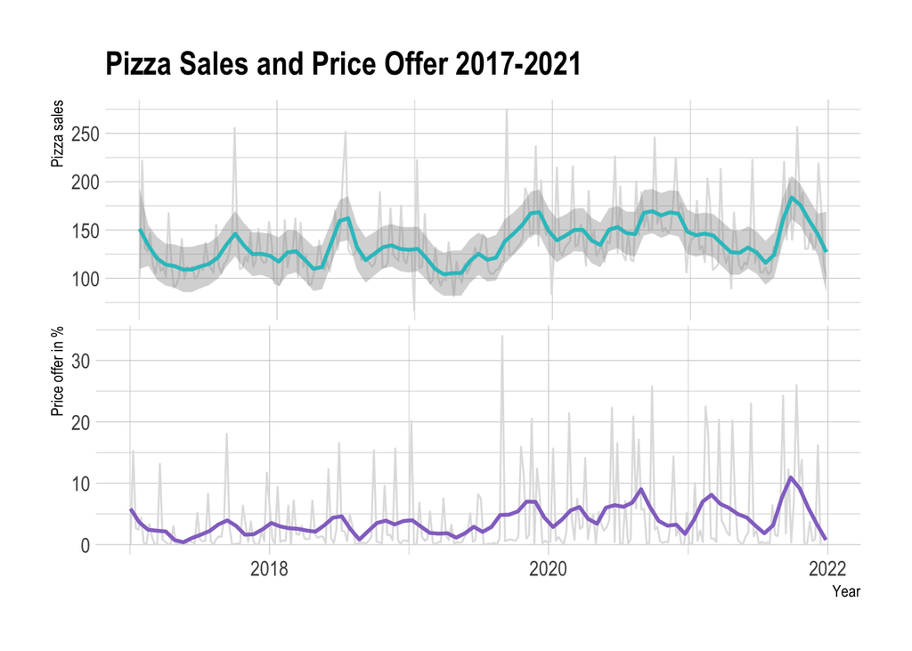

```r
sales_plot <- data %>%
  ggplot(aes(x = date, y = pizza)) +
  ## Add pizza sales
  geom_line(aes(x = date, y = pizza),
    color = "#E0E0E0"
  ) +
  ylim(c(min(data$pizza), max(data$pizza))) +
  ## 4-week moving avg
  stat_smooth(
    method = "loess",
    span = 4 / 52,
    color = "#2EC2C7"
  ) +
  ## Style
  ylab("Pizza sales") +
  theme_ipsum(
    grid = TRUE
  ) +
  theme(
    axis.line.x = element_blank(),
    axis.text.x = element_blank(),
    axis.title.x = element_blank(),
    plot.margin = unit(c(1, 1, 0, 1), "cm")
  )

offer_plot <- data %>%
  ggplot(aes(x = date, y = price_offer)) +
  geom_line(color = "#E0E0E0") +
  ## 4-week moving avg
  stat_smooth(
    method = "loess",
    span = 4 / 52,
    color = "#9474CA",
    se = FALSE
  ) +
  ## Style
  ylab("Price offer in %") +
  theme_ipsum(
    grid = TRUE
  ) +
  xlab("Year") +
  theme(plot.margin = unit(c(0, 1, 1, 1), "cm"))

sales_plot <- sales_plot +
  ggtitle("Pizza Sales and Price Offer 2017-2021")

gridExtra::grid.arrange(sales_plot,
  offer_plot,
  ncol = 1
)
```

Here we can already see a clear correlation between pizza price and sales. Let’s look at the sales data in combination with our own **campaign data.**

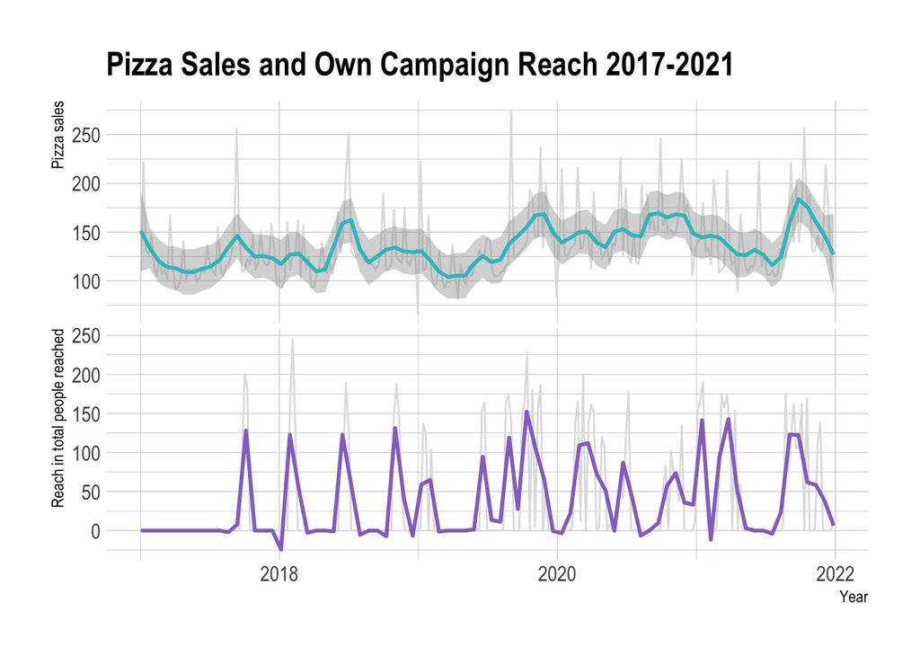

```r
own_campaign_plot <- data %>%
  ggplot(aes(x = date, y = own_campaigns)) +
  geom_line(color = "#E0E0E0") +
  ## 2-week moving avg
  stat_smooth(
    method = "loess",
    span = 2 / 52,
    color = "#9474CA",
    se = FALSE
  ) +
  ## Style
  ylab("Reach in total people reached") +
  theme_ipsum(
    grid = TRUE
  ) +
  xlab("Year") +
  theme(plot.margin = unit(c(0, 1, 1, 1), "cm"))

sales_plot <- sales_plot +
  ggtitle("Pizza Sales and Own Campaign Reach 2017-2021")

gridExtra::grid.arrange(sales_plot,
  own_campaign_plot,
  ncol = 1
)
```

We can see that some but not all campaigns drive our sales. Let’s have a look at our **competitors’ campaigns**. Specifically, we will look at the **total reach of all competitors combined.**

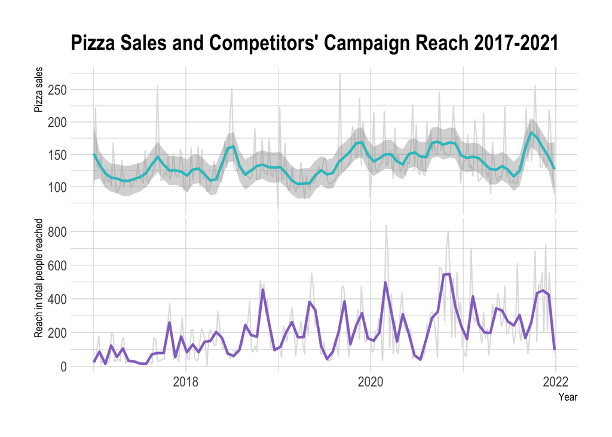

```r
comp_campaign_plot <- data %>%
  ggplot(aes(x = date, y = competitor_campaigns_sum)) +
  geom_line(color = "#E0E0E0") +
  ## 2-week moving avg
  stat_smooth(
    method = "loess",
    span = 2 / 52,
    color = "#9474CA",
    se = FALSE
  ) +
  ## Style
  ylab("Reach in total people reached") +
  theme_ipsum(
    grid = TRUE
  ) +
  xlab("Year") +
  theme(plot.margin = unit(c(0, 1, 1, 1), "cm"))

sales_plot <- sales_plot +
  ggtitle("Pizza Sales and Competitors' Campaign Reach 2017-2021")

gridExtra::grid.arrange(sales_plot,
  comp_campaign_plot,
  ncol = 1
)
```

Let’s look at a **correlation matrix of pizza sales, price offer, own campaign and competitor campaign reach.**

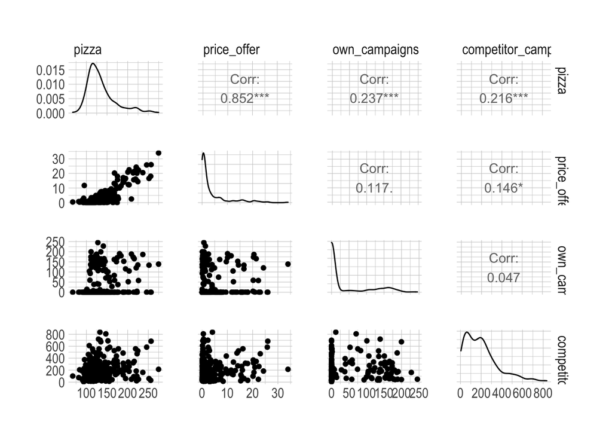

```r
cor_cols <- c(
  "pizza",
  "price_offer",
  "own_campaigns",
  "competitor_campaigns_sum"
)

ggpairs(data, columns = cor_cols) +
  theme_ipsum()
```

These all seem to be great candidates for sales predictors.

Finally, let’s also have a look at the weather variables, i.e., **temperature and precipitation** over the five years, aggregated by month.

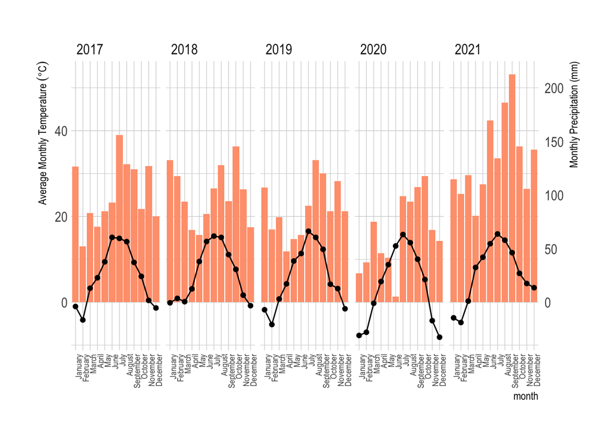

```r
data %>%
  mutate(month = month(date)) %>%
  group_by(month, year) %>%
  summarize(
    temperature = mean(temperature),
    precipitation = mean(precipitation)
  ) %>%
  ggplot(aes(x = month)) +
  geom_bar(aes(y = precipitation, fill = "precipitation"), stat = "identity") +
  geom_line(aes(y = temperature, color = "temperature")) +
  geom_point(aes(y = temperature)) +
  scale_x_discrete(limits = month.name) +
  scale_y_continuous(
    expression("Average Monthly Temperature "(degree * C)),
    sec.axis = sec_axis(~ . * 4, name = "Monthly Precipitation (mm)")
  ) +
  scale_colour_manual("", values = c("temperature" = "black")) +
  scale_fill_manual("", values = "#FFA17D") +
  theme_ipsum() +
  theme(
    axis.text.x = element_text(size = 7, angle = 90, hjust = 1),
    legend.position = "none",
    panel.spacing = unit(0.3, "lines")) +
  facet_wrap(~year,
    ncol = 5
  )
```

**2021 was very rainy,** which might explain the lower pizza sales to some degree. However, it was also the year (almost) post pandemic. Let’s see if a correlation plot could corroborate this assumption.

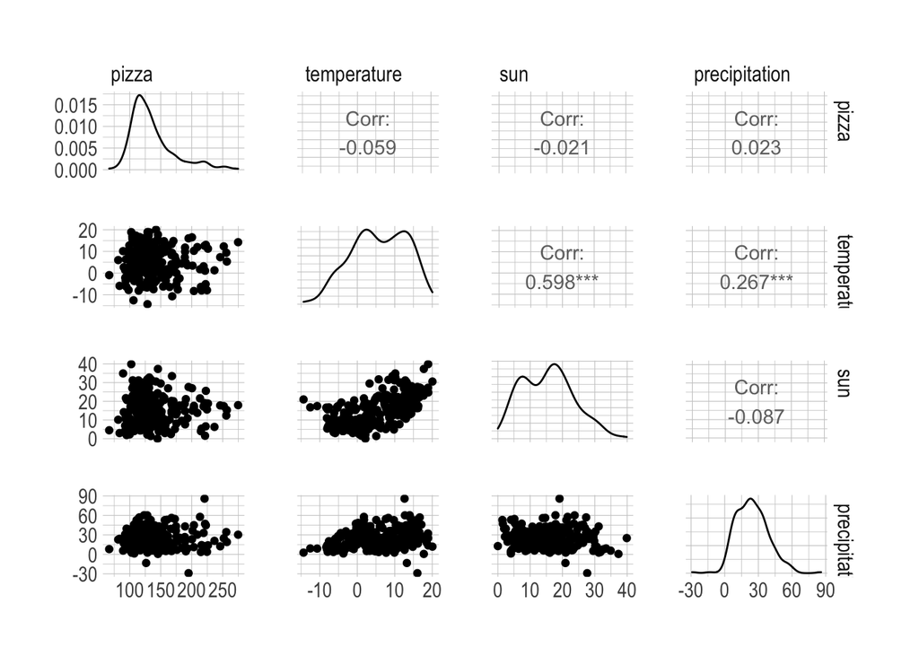

```r
cor_cols <- c(
  "pizza",
  "temperature",
  "sun",
  "precipitation"
)

ggpairs(data, columns = cor_cols) +
  theme_ipsum()
```

Not really. However, **temperature correlates both with hours of sun per day and precipitation in millimeters**, so we might use only temperature as a predictor later on.

For now, we can summarize that **sales offer, our own as well as our competitors’ campaign reach might be valuable sales predictors**.

### Task 2: Summary table

A table with **min, max, total per variable**.

```r
data %>%
  select(
   -c(year,
      week,
      date)
  ) %>%
  gather(variable, value) %>%
  group_by(variable) %>%
  summarize(
    min = min(value),
    max = max(value),
    total = sum(value)
  ) %>%
  tibble()
```

| variable | min | max | total |
| --- | --- | --- | --- |
| campaigns_sum | 4.5000000 | 877.10000 | 62119.201 |
| competitor_1 | 0.0000000 | 272.30150 | 1977.501 |
| competitor_2 | 0.0000000 | 202.70000 | 9971.100 |
| competitor_3 | 0.0000000 | 258.10000 | 12352.000 |
| competitor_4 | 0.0000000 | 234.70000 | 3530.500 |
| competitor_5 | 0.0000000 | 180.20000 | 3171.100 |
| competitor_6 | 4.5000000 | 212.90000 | 16332.900 |
| competitor_7 | 0.0000000 | 243.30000 | 5430.300 |
| competitor_campaigns_mean | 0.6428571 | 119.27143 | 7537.914 |
| competitor_campaigns_sum | 4.5000000 | 834.90000 | 52765.401 |

[output cut: 7 more lines]

### Task 3: Model pizza sales

For this task, we split data into a **training and test set.** Let’s assume we have data only for 2017-2020 and use it to predict the 2021 data.

```r
training <- data %>%
  filter(year != 2021)

predictors <- training[, c(
  "price_offer",
  "own_campaigns",
  "competitor_1",
  "competitor_2",
  "competitor_3",
  "competitor_4",
  "competitor_5",
  "competitor_6",
  "competitor_7",
  "temperature",
  "holiday"
)]

response <- training$pizza

# Define the model and training control
linear_model2 <- train(predictors, response,
  method = "lm",
  trControl = trainControl(method = "cv", number = 5),
  preProcess = c("scale"),
  na.action = na.pass
)

# Print the model summary
print(summary(linear_model2))
```

```
##
## Call:
## lm(formula = .outcome ~ ., data = dat, na.action = ..1)
##
## Residuals:
##     Min      1Q  Median      3Q     Max
## -64.572  -9.599  -1.425   7.130  69.279
##
## Coefficients: (1 not defined because of singularities)
##               Estimate Std. Error t value Pr(>|t|)
## (Intercept)   118.0239     3.0292  38.963  < 2e-16 ***
## price_offer    27.8689     1.1420  24.403  < 2e-16 ***
## own_campaigns   3.7479     1.1756   3.188  0.00167 **
## competitor_1        NA         NA      NA       NA
## competitor_2   -2.2893     1.1477  -1.995  0.04745 *
## competitor_3    0.2433     1.2083   0.201  0.84062
## competitor_4    1.8004     1.6947   1.062  0.28938
## competitor_5    0.1514     1.2667   0.119  0.90500
## competitor_6    0.2505     1.1620   0.216  0.82957
## competitor_7    3.6210     1.6797   2.156  0.03231 *
## temperature    -1.6556     1.1625  -1.424  0.15598
## holiday        -6.8958     1.1422  -6.037 7.66e-09 ***
## ---
## Signif. codes:  0 '***' 0.001 '**' 0.01 '*' 0.05 '.' 0.1 ' ' 1
##
## Residual standard error: 16.15 on 197 degrees of freedom
## Multiple R-squared:  0.7926, Adjusted R-squared:  0.782
## F-statistic: 75.28 on 10 and 197 DF,  p-value: < 2.2e-16
```

Competitor 1 seems to be correlated with our own campaigns or offers. Other than that, we see that the residuals are close to normally distributed, confirming a basic model assumption.

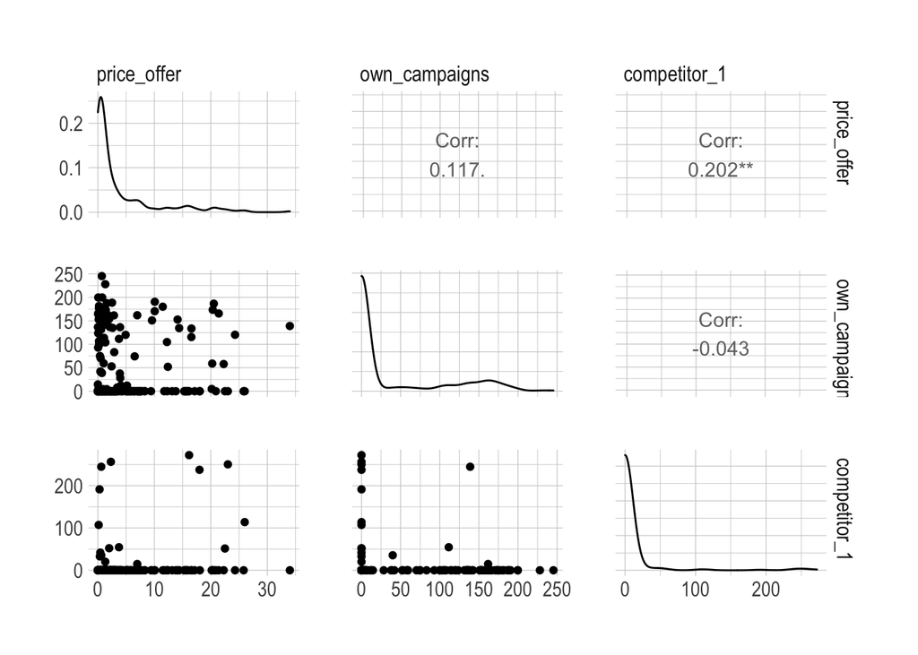

```r
cor_cols <- c(
  "price_offer",
  "own_campaigns",
  "competitor_1"
)

ggpairs(data, columns = cor_cols) +
  theme_ipsum()
```

Competitor 1 seems to run campaigns when our brand has a good price offer, therefore conflating our model. We’ll exclude this competitor.

```r
predictors <- training[, c(
  "price_offer",
  "own_campaigns",
  "competitor_2",
  "competitor_3",
  "competitor_4",
  "competitor_5",
  "competitor_6",
  "competitor_7",
  "temperature",
  "holiday"
)]

response <- training$pizza

# Define the model and training control
linear_model2 <- train(predictors, response,
  method = "lm",
  trControl = trainControl(method = "cv", number = 5),
  preProcess = c("scale"),
  na.action = na.pass
)

# Print the model summary
print(summary(linear_model2))
```

```
##
## Call:
## lm(formula = .outcome ~ ., data = dat, na.action = ..1)
##
## Residuals:
##     Min      1Q  Median      3Q     Max
## -64.572  -9.599  -1.425   7.130  69.279
##
## Coefficients:
##               Estimate Std. Error t value Pr(>|t|)
## (Intercept)   118.0239     3.0292  38.963  < 2e-16 ***
## price_offer    27.8689     1.1420  24.403  < 2e-16 ***
## own_campaigns   3.7479     1.1756   3.188  0.00167 **
## competitor_2   -2.2893     1.1477  -1.995  0.04745 *
## competitor_3    0.2433     1.2083   0.201  0.84062
## competitor_4    1.8004     1.6947   1.062  0.28938
## competitor_5    0.1514     1.2667   0.119  0.90500
## competitor_6    0.2505     1.1620   0.216  0.82957
## competitor_7    3.6210     1.6797   2.156  0.03231 *
## temperature    -1.6556     1.1625  -1.424  0.15598
## holiday        -6.8958     1.1422  -6.037 7.66e-09 ***
## ---
## Signif. codes:  0 '***' 0.001 '**' 0.01 '*' 0.05 '.' 0.1 ' ' 1
##
## Residual standard error: 16.15 on 197 degrees of freedom
## Multiple R-squared:  0.7926, Adjusted R-squared:  0.782
## F-statistic: 75.28 on 10 and 197 DF,  p-value: < 2.2e-16
```

Let’s assemble our **final model.**

```r
predictors <- training[, c(
  "price_offer",
  "own_campaigns",
  "competitor_2",
  "competitor_7",
  "holiday"
)]

response <- training$pizza

# Define the model and training control
linear_model <- train(predictors, response,
  method = "lm",
  trControl = trainControl(method = "cv", number = 5),
  preProcess = c("scale"),
  na.action = na.pass
)

# Print the model summary
print(summary(linear_model))
```

```
##
## Call:
## lm(formula = .outcome ~ ., data = dat, na.action = ..1)
##
## Residuals:
##     Min      1Q  Median      3Q     Max
## -64.988 -10.696  -0.883   7.177  67.256
##
## Coefficients:
##               Estimate Std. Error t value Pr(>|t|)
## (Intercept)    117.454      1.653  71.036  < 2e-16 ***
## price_offer     27.796      1.132  24.561  < 2e-16 ***
## own_campaigns    3.862      1.137   3.395 0.000825 ***
## competitor_2    -1.912      1.125  -1.700 0.090624 .
## competitor_7     5.073      1.132   4.483 1.23e-05 ***
## holiday         -6.751      1.132  -5.962 1.10e-08 ***
## ---
## Signif. codes:  0 '***' 0.001 '**' 0.01 '*' 0.05 '.' 0.1 ' ' 1
##
## Residual standard error: 16.1 on 202 degrees of freedom
## Multiple R-squared:  0.7885, Adjusted R-squared:  0.7833
## F-statistic: 150.7 on 5 and 202 DF,  p-value: < 2.2e-16
```

Again, first-glimpse model diagnostics look promising: Normally distributed residuals and a solid adjusted R-squared indicating that our model is able to explain 78.33% of the variance in the data.

**Let’s test this on the unseen test set (the 2021 data).** Below we see basic model performance metrics **RMS, Rsquared, and MAE.**

```r
test <- data %>%
  filter(year == 2021)

test_predictors <- test[, c(
  "price_offer",
  "own_campaigns",
  "competitor_2",
  "competitor_7",
  "holiday"
)]

predictions <- predict(linear_model, test_predictors)

postResample(predictions, test$pizza)
```

```
##       RMSE   Rsquared        MAE
## 22.1048997  0.7706168 17.8241649
```

We can see that we have a reasonably low prediction error, and the R-squared we get is highly comparable to the one we got for our training set, which is likely due to the cross validation approach we used. Let’s plot the **predicted versus actual pizza sales for 2021.**

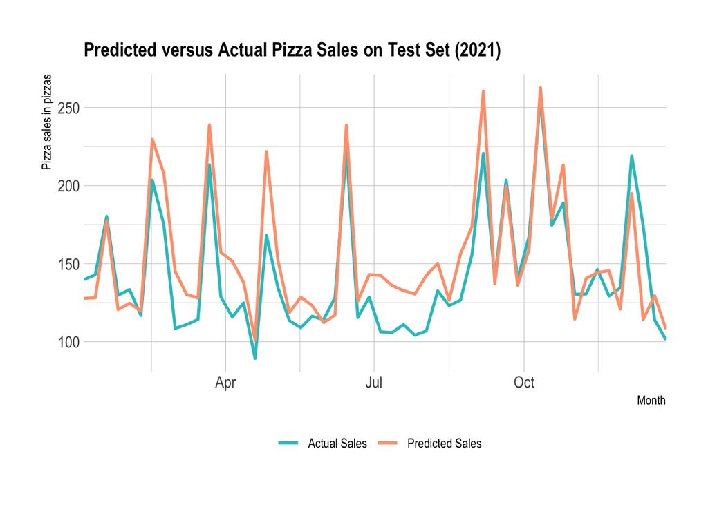

```r
test %>%
  ggplot(aes(
    x = date, y = pizza,
    color = "Actual Sales"
  )) +
  ## Add pizza sales
  geom_line(aes(x = date, y = pizza),
    size = 1
  ) +
  ## Add predictions
  geom_line(aes(
    y = predictions,
    color = "Predicted Sales"
  ),
  size = 1
  ) +
  ## Style
  ggtitle("Predicted versus Actual Pizza Sales on Test Set (2021)") +
  ylab("Pizza sales in pizzas") +
  theme_ipsum(
    plot_title_size = 14,
    grid = TRUE
  ) +
  scale_x_date(expand = c(0, 0)) +
  xlab("Month") +
  scale_color_manual(
    name = "",
    values = c("Actual Sales" = "#2EC2C7", "Predicted Sales" = "#FFA17D")
  ) +
  theme(legend.position="bottom") +
  scale_linetype_manual(
    name = "",
    values = c("Actual Sales" = 1, "Predicted Sales" = 2)
  )
```

We can see that our model does a very good job, though overall slightly overestimating sales.

### Task 4: Selecting predictor variables

The **final model** was `sales ~ price_offer + own_campaigns + competitor_2 + competitor_7 + holiday`. This was based on the following:

1. All own campaigns were combined to one variable since there was no overlap in time between campaigns.
2. `competitor_1` seemed to run campaigns when our brand has good price offers, which leads to correlation of these variables, and was thus removed.
3. The rest of the `competitor_n` campaigns were removed based on the low influence on our sales variable as indicated by their coefficients.
4. Weather variables `sun` and `precipitation` were removed since they correlated both with temperature.
5. `temperature` was removed based on its coefficient.
6. `holiday` had a strong negative impact, possibly indicating that some stores selling our product are closed on these days and therefore stayed in the model.